# data-analysis-replication

Jessica V

2024-04-15

# *PROJECT NOT YET COMPLETED loading up PDF and imnages now

# *OBJECTIVE:*

The overall objective of Legendre et al., 2016 was to estimate metabolic rates of fossil archosauromorphs (a major group of diapsids, differentiated from the other diapsids by the presence of single openings in each side of the skull, in front of the eyes, among other characteristics) by performing a statistical predictive model using a new method of phylogenetic eigenvector maps on a set of bone histological features for a sample of extant and extinct vertebrates.

# TYPES OF *DATA COLLECTED:*

The models were built using 57 specimens belonging to 14 extant species and 14 extinct species of tetrapods.

Resting metabolic rates (RMR values) are taken from Montes et al. (2007), where growth rate was taken from juvinile specimens in vivo. (All variables, such as histological characters and metabolic were taken from the same specimen.) Bone histology sections were used for obtaining the following measurements: vascular density, osteocyte density, osteocyte shape, and osteocyte area—on each bone.

Phylogeny relationships, topology and branch length, a well as inner relationships were all taken from published sources (Cubo et al. (2012), Legendre et al. (2013), Benton et al. 2015), Conrad (2008), Joyce et al. (2013), Nesbitt (2011), and Crawford et al. (2015)).

# The *MAIN RESULTS* of the paper showed:

1. that Mesozoic theropod dinosaurs exhibit metabolic rates very close to those found in modern birds
2. that archosaurs share a higher ancestral metabolic rate than that of extant ectotherms 3)that this derived high metabolic rate was acquired at a much more inclusive level of the phylogenetic tree, among non-archosaurian archosauromorphs.

Additionally, these results highlight the difficulties of assigning a given heat production strategy, such as endothermy or ectothermy, to an estimated metabolic rate value. The results of the paper also confirmed findings from previous studies which state that the definition of the endotherm/ectotherm dichotomy may be ambiguous.

# *ANALYSIS* DONE:

The PEM approach was selected to estimate mass-specific RMR (in mL O2 h−1 g−0.67 ) in this study, using bone histological data and phylogenetic information to convert the phylogeny into PEMs and predict values of the dependent variable for fossil species. Three predictive models were done for each of the three elements (femur, humerus, and tibia), to maintain a strict frame of homology. Ancestral states of RMR were reconstructed from both observed and predicted values, using a phylogeny of the complete sample.

# *ANALYSIS REPLICATED*

Visualization:

Here I replicated the sepratate components of Figure 1. Separate images have been coded below as the original work was tied together using a program other than R.

statistical analysis, one inferential statistical analysis:

These are the packages that I used for this replication:

```r
library(TreeTools)
```

```r
library(ape)
library(ggplot2)
library(tidyverse)
library(ggtree)
library(BiocManager)
library(ggtree)
library(phytools)
library(maps)
library(gridExtra)
library(MPSEM)
library(evobiR)
library(Metrics)
```

# *Visualization of Data*

Legendre et al., 2016 has made their data available at “https://datadryad.org/stash/dataset/doi:10.5061/dryad.2853k”.

The following data files were downloaded from Dryad to my computer: femurfilemeta.txt, humerusfilemeta.txt, tibiafilemeta.txt, Treecomplete.trees.nex, TreefemurMeta.nex,TreehumerusMeta.nex, TreetibiaMeta.nex.

I downloaded the filed from Dryad and saved them into a folder called DATA in my repo.The files then loaded into R through my directory as indicated below. I titled each data by the bone it refers to and viewed the head of the data.

```r
f<- "/Users/jessicavaldes/Desktop/R2024/FINAL.PROJECT/tibiafilemeta.txt"

tibia <- read.delim(f, stringsAsFactors = FALSE, fileEncoding = "latin1")

head(tibia)
```

```
##                Species Resting.metabolic.rate..mLO2.h.1.g.0.67.
## 1   Anas platyrhynchos                                   10.865
## 2      Cavia porcellus                                    3.477
## 3    Chelodina oblonga                                    0.085
## 4 Crocodylus niloticus                                    0.336
## 5         Mus musculus                                    1.696
## 6  Pelodiscus sinensis                                    0.083
##   Vascular.density..vascular.canals.mm2. Osteocyte.density..osteocyte.µm2.
## 1                              149.98293                       0.002240553
## 2                              107.37029                       0.001741841
## 3                                0.00000                       0.001542919
## 4                               37.28672                       0.000996448
## 5                               96.90753                       0.002313816
## 6                                0.00000                       0.009798535
##   Osteocyte.area..µm2. Osteocyte.shape
## 1             19.06359       0.5162245
## 2             31.00008       0.4621071
## 3             19.95596       0.5885283
## 4             31.43206       0.4798113
## 5             35.12016       0.5290672
## 6             24.91903       0.4708612
```

```r
f<- "/Users/jessicavaldes/Desktop/R2024/FINAL.PROJECT/humerusfilemeta.txt"

humerus <- read.delim(f, stringsAsFactors = FALSE, fileEncoding = "latin1")

head(humerus)
```

```
##                Species Resting.metabolic.rate..mLO2.h.1.g.0.67.
## 1   Anas platyrhynchos                                   10.865
## 2      Cavia porcellus                                    3.477
## 3    Chelodina oblonga                                    0.085
## 4 Crocodylus niloticus                                    0.336
## 5         Mus musculus                                    1.696
## 6  Pelodiscus sinensis                                    0.083
##   Vascular.density..vascular.canals.mm2. Osteocyte.density..osteocyte.µm2.
## 1                              172.94813                       0.002283169
## 2                              112.74807                       0.001966108
## 3                                0.00000                       0.001208368
## 4                               48.95666                       0.000699242
## 5                               98.51727                       0.001230761
## 6                                0.00000                       0.001185422
##   Osteocyte.area..µm2. Osteocyte.shape
## 1             24.29137       0.5091267
## 2             34.98627       0.4854710
## 3             24.27797       0.5633677
## 4             34.60153       0.4854308
## 5             22.62413       0.5262539
## 6             20.92560       0.4971409
```

```r
f<- "/Users/jessicavaldes/Desktop/R2024/FINAL.PROJECT/femurfilemeta.txt"

femur <- read.delim(f, stringsAsFactors = FALSE, fileEncoding = "latin1")

head(femur)
```

```
##                Species Resting.metabolic.rate..mLO2.h.1.g.0.67.
## 1   Anas platyrhynchos                                   10.865
## 2      Cavia porcellus                                    3.477
## 3    Chelodina oblonga                                    0.085
## 4 Crocodylus niloticus                                    0.336
## 5         Mus musculus                                    1.696
## 6  Pelodiscus sinensis                                    0.083
##   Vascular.density..vascular.canals.mm2. Osteocyte.density..osteocyte.µm2.
## 1                              128.69453                       0.002567298
## 2                              106.28102                       0.001875300
## 3                                0.00000                       0.000972828
## 4                               33.07733                       0.000707445
## 5                              183.78853                       0.001222124
## 6                                0.00000                       0.000913358
##   Osteocyte.area..µm2. Osteocyte.shape
## 1             20.64402       0.4962566
## 2             34.15500       0.4972518
## 3             28.12464       0.6153665
## 4             29.69357       0.4747210
## 5             29.48473       0.4804544
## 6             24.48596       0.5219174
```

Here I have loaded the tree data by reading the NEXUS file and naming them by the component (tibia, humerus, femus, or complete) and adding “tree” in the name.

```r
tibiatree <- read.nexus(file = "/Users/jessicavaldes/Desktop/R2024/Final.Project2024/DATA/TreetibiaMeta.nex")

head(tibiatree)
```

```
## $edge
##       [,1] [,2]
##  [1,]   24   14
##  [2,]   24   25
##  [3,]   25   26
##  [4,]   26   12
##  [5,]   26   27
##  [6,]   27    2
##  [7,]   27    5
##  [8,]   25   28
##  [9,]   28   29
## [10,]   29   30
## [11,]   30    7
## [12,]   30    8
## [13,]   29   31
```

[output cut: 48 more lines]

```r
humerustree <- read.nexus(file = "/Users/jessicavaldes/Desktop/R2024/Final.Project2024/DATA/TreehumerusMeta.nex")

head(humerustree)
```

```
## $edge
##       [,1] [,2]
##  [1,]   19   14
##  [2,]   19   20
##  [3,]   20   21
##  [4,]   21   12
##  [5,]   21   22
##  [6,]   22    2
##  [7,]   22    5
##  [8,]   20   23
##  [9,]   23   24
## [10,]   24   25
## [11,]   25    7
## [12,]   25    8
## [13,]   24   26
```

[output cut: 35 more lines]

```r
femurtree <- read.nexus(file = "/Users/jessicavaldes/Desktop/R2024/Final.Project2024/DATA/TreefemurMeta.nex")

head(femurtree)
```

```
## $edge
##       [,1] [,2]
##  [1,]   22   14
##  [2,]   22   23
##  [3,]   23   24
##  [4,]   24   12
##  [5,]   24   25
##  [6,]   25    2
##  [7,]   25    5
##  [8,]   23   26
##  [9,]   26   27
## [10,]   27   28
## [11,]   28    7
## [12,]   28    8
## [13,]   27   29
```

[output cut: 44 more lines]

```r
completetree <- read.nexus(file =   "/Users/jessicavaldes/Desktop/R2024/Final.Project2024/DATA/Treecomplete.trees.nex")

head(completetree)
```

```
## $edge
##       [,1] [,2]
##  [1,]   29   14
##  [2,]   29   30
##  [3,]   30   31
##  [4,]   31   12
##  [5,]   31   32
##  [6,]   32    2
##  [7,]   32    5
##  [8,]   30   33
##  [9,]   33   34
## [10,]   34   35
## [11,]   35    7
## [12,]   35    8
## [13,]   34   36
```

[output cut: 60 more lines]

# COMPLETE TREE:

Here I start replicating the complete tree show in in Figure 1 of the paper. I made sure the NEXUS file was loaded.

I converter the complete tree into a phylo object.

I plotted the phylo tree using ggtree, add tip labels (shows the species name in this case) and apply a tree-like theme, and name it Main Tree

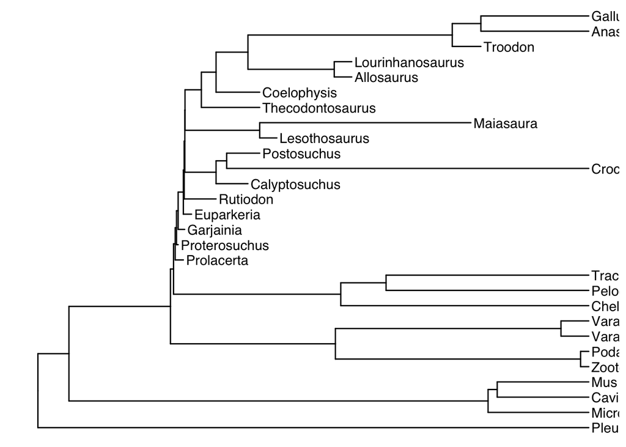

```r
completetree <- read.nexus(file = "/Users/jessicavaldes/Desktop/R2024/Final.Project2024/DATA/Treecomplete.trees.nex")

phylocomplete <- as.phylo(completetree)


Maintree <- ggtree(phylocomplete) +
  geom_tiplab() +
  theme_tree()

plot(Maintree)
```

Although the Maintree produced has the correct data, it does not look like the image in Figure 1 yet.

Here I rotate each of the nodes individually. (Note: I use the phylo object in order to be able to rotate the nodes using the rotate.multi function). I name the correctly rotated tree L1.

I visualize the tree as a Cladogram (or rectangular layout) as the paper does by modifying the lengths of the branches from the tree and name it LL1.

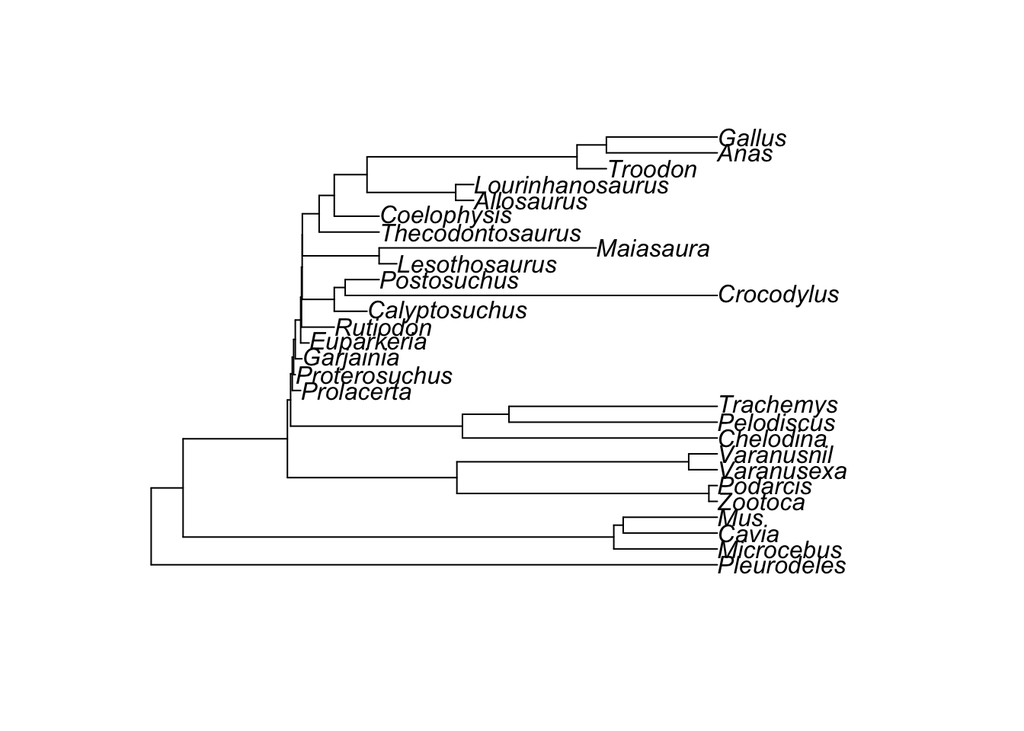

```r
plot(phylocomplete)
```

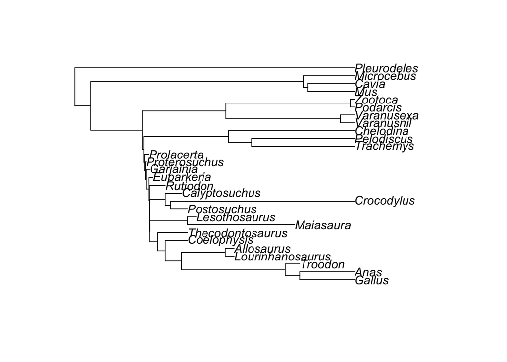

```r
L1<- rotate.multi(phylocomplete, 29)

L1<- rotate.multi(L1, 30)
L1<- rotate.multi(L1, 31)
L1<- rotate.multi(L1, 32)
L1<- rotate.multi(L1, 33)
L1<- rotate.multi(L1, 34)
L1<- rotate.multi(L1, 35)
L1<- rotate.multi(L1, 36)
L1<- rotate.multi(L1, 37)
L1<- rotate.multi(L1, 38)
L1<- rotate.multi(L1, 39)
L1<- rotate.multi(L1, 40)
L1<- rotate.multi(L1, 41)
L1<- rotate.multi(L1, 42)
L1<- rotate.multi(L1, 43)
L1<- rotate.multi(L1, 44)
L1<- rotate.multi(L1, 45)
L1<- rotate.multi(L1, 46)
L1<- rotate.multi(L1, 47)
L1<- rotate.multi(L1, 48)
L1<- rotate.multi(L1, 49)
L1<- rotate.multi(L1, 50)
L1<- rotate.multi(L1, 51)
L1<- rotate.multi(L1, 52)
L1<- rotate.multi(L1, 53)
L1<- rotate.multi(L1, 54)
L1<- rotate.multi(L1, 55)


plot(L1)
```

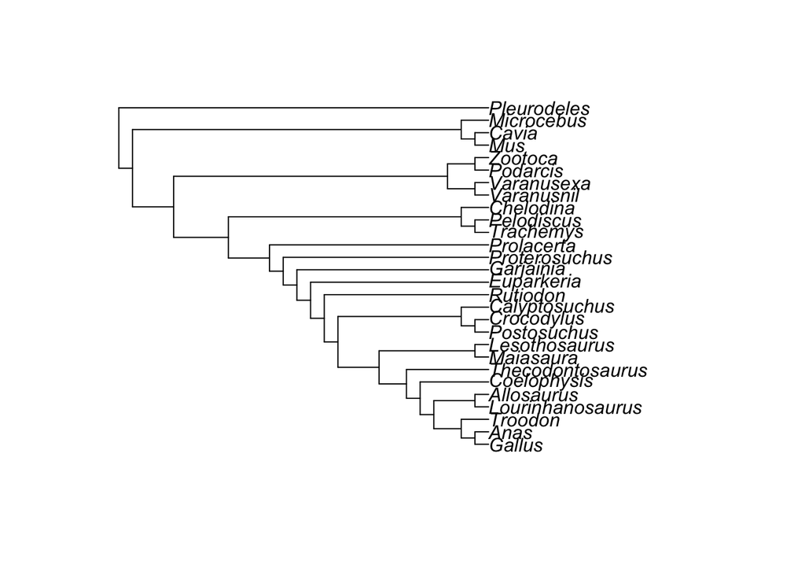

```r
LL1<-compute.brlen(L1, length =1)

plot(LL1)
```

This tree how looks like the Left side of Figure 1. Here I insert an image of Figure 1 to view for comparison.

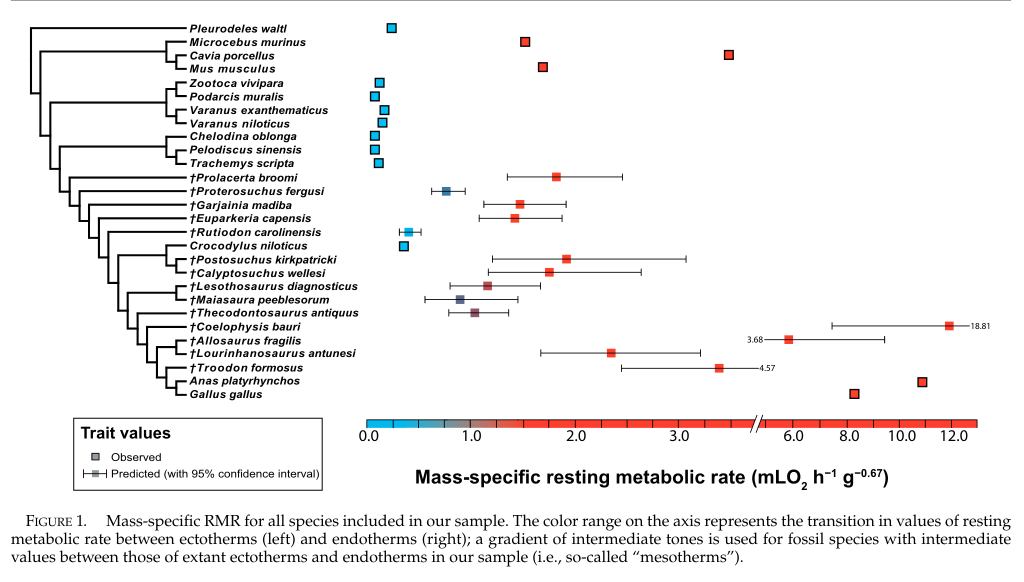

```r
knitr::include_graphics("IMAGES/Legendre2016Figure1.png")
```

Now that the tree is replicated I am moving onto the right part of Figure 1 (for the purposes of this report, I am calling this image replication Part 2).

For Part 2, I need to combine all of the RMR of all of the species provided with the three sets of data (tibia, humerus, and femur.)

In order to make my life easier when combining this data I start by changing the names of the Resting Metabolic Rate columns to “RMR”. I then check the column names to make sure I have the correct new column name titles.

```r
colnames(tibia)[2] <- "RMR"
colnames(humerus)[2] <- "RMR"
colnames(femur)[2] <- "RMR"

colnames(tibia)
```

```
## [1] "Species"
## [2] "RMR"
## [3] "Vascular.density..vascular.canals.mm2."
## [4] "Osteocyte.density..osteocyte.µm2."
## [5] "Osteocyte.area..µm2."
## [6] "Osteocyte.shape"
```

```r
colnames(humerus)
```

```
## [1] "Species"
## [2] "RMR"
## [3] "Vascular.density..vascular.canals.mm2."
## [4] "Osteocyte.density..osteocyte.µm2."
## [5] "Osteocyte.area..µm2."
## [6] "Osteocyte.shape"
```

```r
colnames(femur)
```

```
## [1] "Species"
## [2] "RMR"
## [3] "Vascular.density..vascular.canals.mm2."
## [4] "Osteocyte.density..osteocyte.µm2."
## [5] "Osteocyte.area..µm2."
## [6] "Osteocyte.shape"
```

Here I combine all RMR from all bone datasets. I combine all Species from all bone datasets. I cbind Species and RMR, removing NA’s and duplicates, and name the final dataset allSpeciesRMR1.

```r
allRMR <- data.frame(RMR = c(femur$RMR, tibia$RMR, humerus$RMR))
allSpecies <- data.frame(Species = c(femur$Species, tibia$Species, humerus$Species))
allsSpeciesRMR <- cbind(allSpecies, allRMR)

allSpeciesRMR <- drop_na(allsSpeciesRMR)

allSpeciesRMR1 <- allSpeciesRMR %>% distinct(Species, .keep_all = TRUE)
```

Now that I have all of the data together I can generate the plot. Here I plot RMR on the x-axis and Species on the Y-axis I make sure the shapes are squares (shape 15) I makes values less than 1 blue, and values more than 1 red.

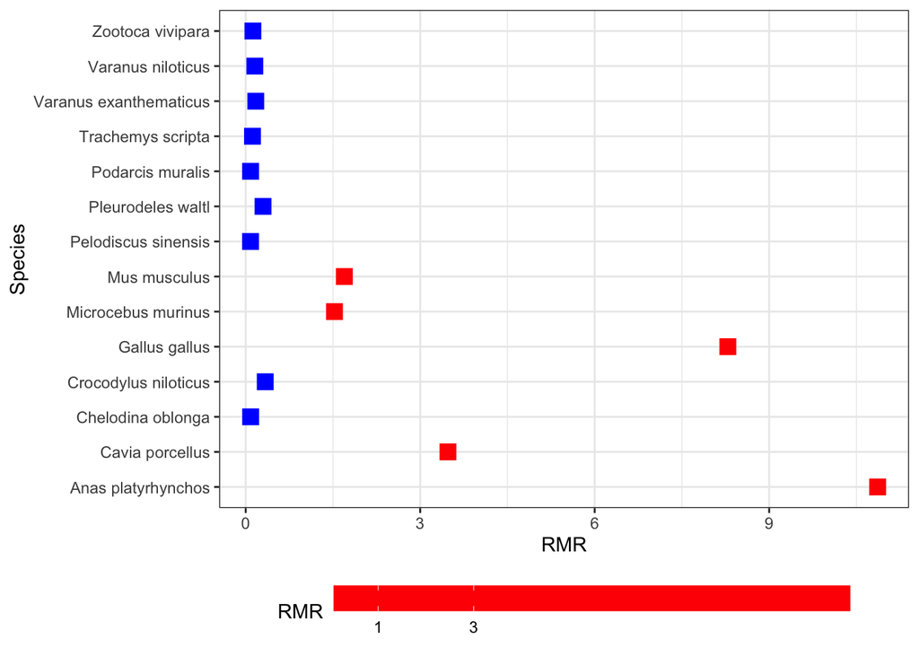

```r
firstplot <- (ggplot(allSpeciesRMR1, aes(x = RMR, y = Species)) +
  geom_point(shape = 15, size = 4, aes(fill = RMR, colour = ifelse(RMR < 1, "blue", "red"))) +
  scale_colour_identity() +
  scale_fill_identity() +
    scale_fill_gradient(low = "red", high = "red", breaks = c(0, 1, 3), labels = c("0", "1", "3"))+
  guides(colour = FALSE) +
 theme_bw() +
  theme(legend.position="bottom", legend.key.size = unit(.5, "cm"),
  legend.key.width = unit(2,"cm")))
plot(firstplot)
```

I then realize that the data above only contains the data provided in the data from dryad.

In order to have all of the data reported on Figure 1, I have manually added all of the Table 1 data from the paper below(Species, RMR, UL, and LL), and cbind them into a dataframe called missingspecies. I then convert to the same type of data and join this data with the previous data above into a dataframe called full data.

```r
Species <- c("Prolacerta broomi", "Proterosuchus fergusi", "Garjainia madiba", "Euparkeria capensis", "Rutiodon carolinensis", "Calyptosuchus wellesi", "Postosuchus kirkpatricki", "Lesothosaurus diagnosticus", "Maiasaura peeblesorum", "Thecodontosaurus antiquus", "Coelophysis bauri", "Lourinhanosaurus antunesi", "Allosaurus fragilis", "Troodon formosus")
RMR<- c(1.779574478, 0.742796421, 1.428587942, 1.388275876, 0.395353151, 1.707702381, 1.864455587, 1.130079749, 0.861329988, 1.002164215, 11.83642213, 2.285600254, 5.889620032, 3.301842183)
LL <- c(1.319254894,0.604057894, 1.093892708, 1.05448569, 0.308843779, 1.135032404, 1.165933134, 0.78543557, 0.532978612, 0.760912118, 7.44819231, 1.624566141, 3.680724942, 2.388193685)
UL <- c(2.401309306, 0.914306682, 1.865918168, 1.827725139, 0.506094433, 2.569307738, 2.981470097, 1.630369802, 1.400681483, 1.319906895, 18.81005185, 3.215608472, 9.478280852, 4.56502413)

missingspecies <- cbind(Species, RMR, LL, UL)
missingspecies <- as.data.frame(missingspecies)
colnames(missingspecies)
```

```
## [1] "Species" "RMR"     "LL"      "UL"
```

```r
colnames(allSpeciesRMR1)
```

```
## [1] "Species" "RMR"
```

```r
class(allSpeciesRMR1)
```

```
## [1] "data.frame"
```

```r
class(missingspecies)
```

```
## [1] "data.frame"
```

```r
missingspecies <- mutate(missingspecies, RMR = as.double(RMR))

fulldata<- (full_join(allSpeciesRMR1, missingspecies, by = c("RMR", "Species")))

fulldata
```

```
##                       Species        RMR          LL          UL
## 1          Anas platyrhynchos 10.8650000        <NA>        <NA>
## 2             Cavia porcellus  3.4770000        <NA>        <NA>
## 3           Chelodina oblonga  0.0850000        <NA>        <NA>
## 4        Crocodylus niloticus  0.3360000        <NA>        <NA>
## 5                Mus musculus  1.6960000        <NA>        <NA>
## 6         Pelodiscus sinensis  0.0830000        <NA>        <NA>
## 7            Zootoca vivipara  0.1240000        <NA>        <NA>
## 8            Podarcis muralis  0.0840000        <NA>        <NA>
## 9           Trachemys scripta  0.1170000        <NA>        <NA>
## 10     Varanus exanthematicus  0.1730000        <NA>        <NA>
## 11          Varanus niloticus  0.1570000        <NA>        <NA>
## 12         Microcebus murinus  1.5260000        <NA>        <NA>
## 13              Gallus gallus  8.2890000        <NA>        <NA>
## 14          Pleurodeles waltl  0.2980000        <NA>        <NA>
## 15          Prolacerta broomi  1.7795745 1.319254894 2.401309306
## 16      Proterosuchus fergusi  0.7427964 0.604057894 0.914306682
## 17           Garjainia madiba  1.4285879 1.093892708 1.865918168
## 18        Euparkeria capensis  1.3882759  1.05448569 1.827725139
## 19      Rutiodon carolinensis  0.3953532 0.308843779 0.506094433
## 20      Calyptosuchus wellesi  1.7077024 1.135032404 2.569307738
## 21   Postosuchus kirkpatricki  1.8644556 1.165933134 2.981470097
## 22 Lesothosaurus diagnosticus  1.1300797  0.78543557 1.630369802
## 23      Maiasaura peeblesorum  0.8613300 0.532978612 1.400681483
## 24  Thecodontosaurus antiquus  1.0021642 0.760912118 1.319906895
## 25          Coelophysis bauri 11.8364221  7.44819231 18.81005185
## 26  Lourinhanosaurus antunesi  2.2856003 1.624566141 3.215608472
## 27        Allosaurus fragilis  5.8896200 3.680724942 9.478280852
## 28           Troodon formosus  3.3018422 2.388193685  4.56502413
```

The data is now ready to be fully plotted.

Here I plot the full dataset, using shapes and colors like the paper. I understand that this paper was published before R packages were as advanced as they are now, thus the author created images outside of R. So this image has more similar colors to that of the image created outside of R.

In order to match the original image better, I change “blue” to “light blue” #Add a title to the x-axis #add a scale gradient to the legend along with the breaks the paper has. #remove the grey background

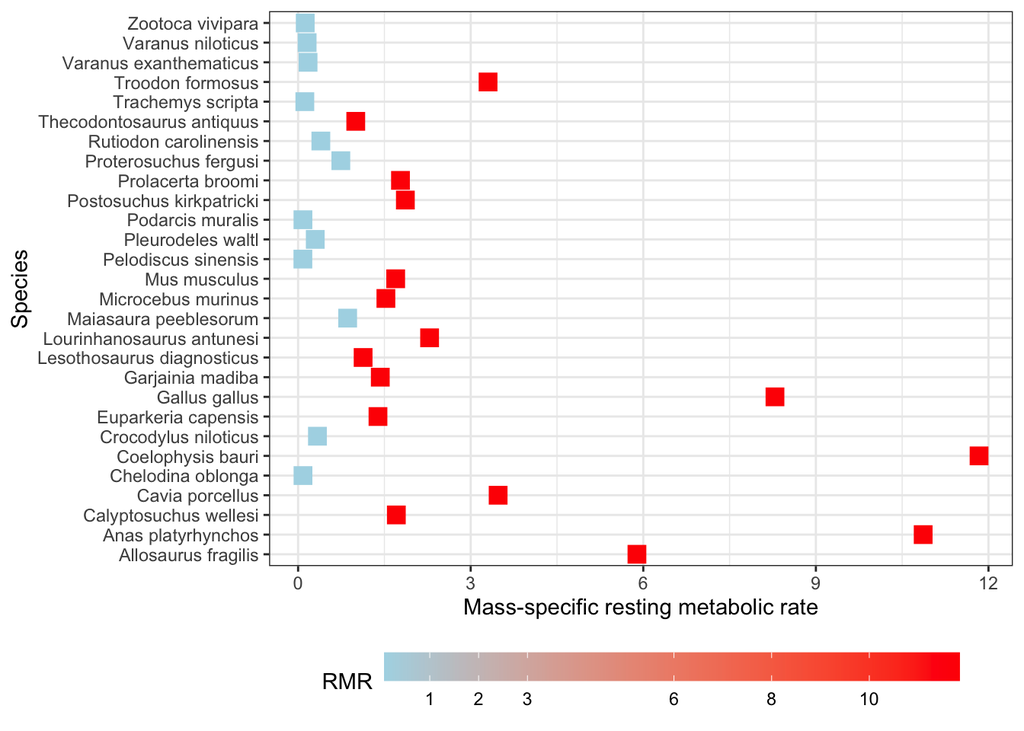

```r
plot2 <-(ggplot(fulldata, aes(x = RMR, y = Species)) +
  geom_point(shape = 15, size = 4, aes(fill = RMR, colour = ifelse(RMR < 1, "light blue", "red"))) +
  labs( x = "Mass-specific resting metabolic rate") +
scale_colour_identity() +
  scale_fill_identity() +
    scale_fill_gradient(low = "light blue", high = "red", breaks = c(0, 1, 2, 3, 6, 8, 10, 12), labels = c("0", "1", "2", "3", "6", "8", "10", "12"))+
  guides(colour = FALSE) +
 theme_bw() +
  theme(legend.position="bottom", legend.key.size = unit(.5, "cm"),
  legend.key.width = unit(2,"cm")))
plot(plot2)
```

Here I have created a second image using fill gradients I changed the shape to 22 as the squares are outlined in the paper and save image as FIGURE1

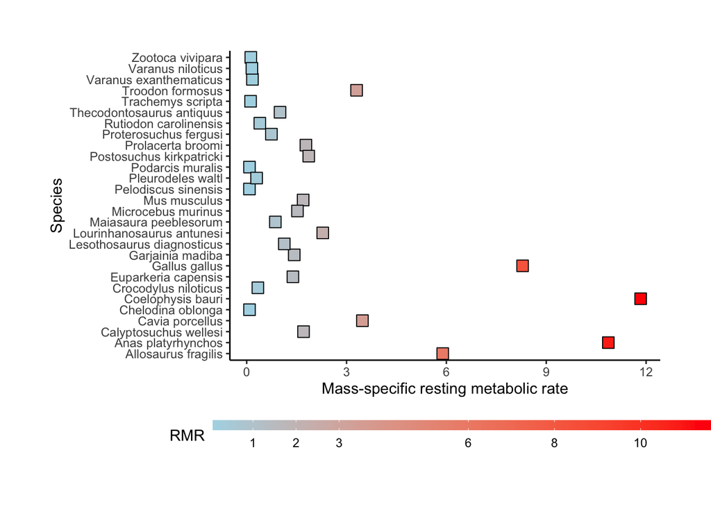

```r
FIGURE1 <- (ggplot(fulldata, aes(x = RMR, y = Species)) +
   geom_point(shape = 22, size = 4, color = "black", aes(fill = RMR, colour = ifelse(RMR < 1, "light blue", "red"))) +
   labs( x = "Mass-specific resting metabolic rate") +
  scale_colour_identity() +
    scale_fill_identity() +
     scale_fill_gradient(low = "light blue", high = "red", breaks = c(0, 1, 2, 3, 6, 8, 10, 12), labels = c("0", "1", "2", "3", "6", "8", "10", "12"))+
   guides(colour = FALSE) +
  theme_classic() +
  theme(plot.margin = unit(c(0.5, 0.5, 0.5, 0.5),
                                "inches")) +
    theme(legend.position="bottom", legend.key.size = unit(.1, "inches"),
   legend.key.width = unit(1,"inches")))
plot(FIGURE1)
```

I made sure RMR, UL, amd LL were numeric and added the errorbars to the plot naming it fixingscale.

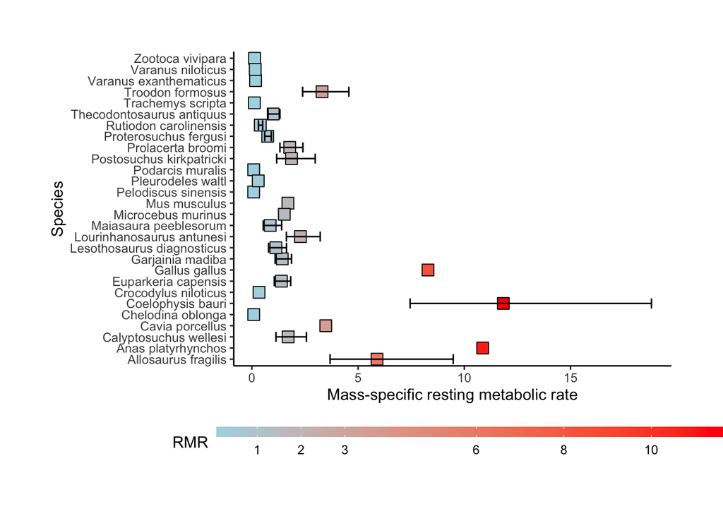

```r
fulldata$RMR<-as.numeric(fulldata$RMR)
fulldata$UL<-as.numeric(fulldata$UL)
fulldata$LL<-as.numeric(fulldata$LL)


fixingscale <- (ggplot(fulldata , aes(x = RMR, y = Species)) +
   geom_point(shape = 22, size = 4, color = "black", aes(fill = RMR)) +
   labs( x = "Mass-specific resting metabolic rate") +
     scale_fill_gradient(low = "light blue", high = "red", breaks = c(0, 1, 2, 3, 6, 8, 10, 12), labels = c("0", "1", "2", "3", "6", "8", "10", "12"))+
  theme_classic() +
    geom_errorbarh(aes(xmax=UL, xmin=LL)) +
  theme(plot.margin = unit(c(0.5, 0.5, 0.5, 0.5), "inches")) +
    theme(legend.position="bottom", legend.key.size = unit(.1, "inches"),
   legend.key.width = unit(1,"inches")))



plot(fixingscale)
```